# Examen final de Introducción a R - Versión A

- Mostrar todo el código
- Ocultar todo el código
- Ver el código fuente

Bioinformática I — Versión A

Autor/a

Adrik Daniel Cornejo Molina

## Instrucciones generales

**Duración: 120 minutos. Valor total: 100 puntos.**

El objetivo es reproducir dos figuras a partir de datos reales de mieles de abejas sin aguijón. Los conteos proporcionados corresponden únicamente a bacterias con asignación taxonómica a nivel de género. Se incluyen 17 muestras de dos especies de abejas.

Trabaja en tu proyecto de RStudio y utiliza este documento como [plantilla](https://github.com/CursosENESJuriquilla/Intro_to_R_Bioinfo_2027-1/raw/refs/heads/main/versionA.qmd). Sustituye el nombre del autor por el tuyo. Agrega tus bloques de código R ejecutables y tus respuestas en las secciones correspondientes. Conserva las rutas relativas y muestra el procedimiento completo. Las figuras de referencia son una guía: no es necesario reproducir exactamente la tipografía ni los tamaños.

## Importación y exploración (10 puntos)

Descarga y descomprime datos_A.zip. Importa con `readr` los archivos `conteos_genero_miel_bacterias.tsv` y `datos/metadata_miel_examen.csv`.

- Indica las dimensiones de ambas tablas y el número de muestras por especie de abeja.
- Identifica si existen valores faltantes en los metadatos e indica en qué variable o variables.

**Código**

```r
library(readr)
library(purrr)
library(dplyr)
library(tidyr)
library(tibble)
library(ggplot2)
```

**Código**

```r
# Cargar archivo
conteos <- read_tsv('datos_A/conteos_genero_miel_bacterias.tsv',
                    show_col_types = FALSE)
meta <- read.csv('datos_A/metadata_miel_examen.csv')

cat('_____________________________________________________________________\n')
```

```
_____________________________________________________________________
```

**Código**

```r
# Verificar que se lean correctamente
# head(conteos, 1)
# head(meta, 1)

cat('_____________________________________________________________________\n')
```

```
_____________________________________________________________________
```

**Código**

```r
# Dimensiones
cat('Las dimenciones (filas, columnas) del archivo de los conteos es:\n'
    , dim(conteos), '\n\n')
```

```
Las dimenciones (filas, columnas) del archivo de los conteos es:
 37128 3
```

**Código**

```r
cat('Las dimenciones (filas, columnas) del archivo metadata es:\n'
    , dim(meta), '\n\n')
```

```
Las dimenciones (filas, columnas) del archivo metadata es:
 17 14
```

**Código**

```r
cat('_____________________________________________________________________\n')
```

```
_____________________________________________________________________
```

**Código**

```r
# Valores Faltantes
cat('Hay valores faltantes hay en el archivo de conteos:\n',
    anyNA(conteos), '\n\n')
```

```
Hay valores faltantes hay en el archivo de conteos:
 FALSE
```

**Código**

```r
cat('Hay valores faltantes hay en el archivo de conteos:\n',
    anyNA(meta), '\nDonde?\n',
    names(which(colSums(is.na(meta)) > 0)), '\nEn que filas?\n',
    which(!complete.cases(meta)), '\n\n'
)
```

```
Hay valores faltantes hay en el archivo de conteos:
 TRUE
Donde?
 Total_sugar
En que filas?
 9 14
```

**Código**

```r
cat('_____________________________________________________________________\n')
```

```
_____________________________________________________________________
```

**Código**

```r
# Muestras por especie de abeja

cat('Muestras por especie de abeja:')
```

```
Muestras por especie de abeja:
```

**Código**

```r
sort(table(meta$species), decreasing = TRUE)
```

```
     Melipona beecheii Scaptotrigona mexicana
                     9                      8
```

## Integración y abundancia relativa (20 puntos)

Integra las dos tablas mediante el identificador `sample_id`. Calcula la abundancia relativa de cada género dentro de cada muestra, dividiendo su conteo entre la suma de los conteos de esa muestra. Conserva las abundancias como proporciones entre 0 y 1.

**Código**

```r
cat('_____________________________________________________________________\n')
```

```
_____________________________________________________________________
```

**Código**

```r
# Integracion

integracion <- conteos %>%
  left_join(meta, by = "sample_id")

cat('_____________________________________________________________________\n')
```

```
_____________________________________________________________________
```

**Código**

```r
# Abundancia relativa

abundancia_rel <- integracion %>%
  group_by(sample_id) %>%
  mutate(abundancia_relativa = conteo / sum(conteo)) %>%
  ungroup() %>%
  select(sample_id, genero, abundancia_relativa)
head(abundancia_rel, 10)
```

```
# A tibble: 10 × 3
   sample_id genero             abundancia_relativa
   <chr>     <chr>                            <dbl>
 1 Melli_21  Abiotrophia                0.000132
 2 Melli_21  Abyssalbus                 0.0000108
 3 Melli_21  Abyssibius                 0.000000491
 4 Melli_21  Abyssicoccus               0.000140
 5 Melli_21  Acaryochloris              0.000142
 6 Melli_21  Aceticella                 0.00000180
 7 Melli_21  Acetilactobacillus         0.660
 8 Melli_21  Acetivibrio                0.0000753
 9 Melli_21  Acetoanaerobium            0.0000142
10 Melli_21  Acetobacter                0.0000258
```

## Figura 1: los 10 géneros más abundantes (25 puntos)

Calcula la abundancia relativa promedio de cada género considerando las 17 muestras, incluidos los conteos cero. Selecciona los diez con mayor promedio y reproduce la gráfica de barras horizontales ordenadas de mayor a menor. Muestra el eje de abundancia en porcentajes y agrega etiquetas apropiadas.

[figure not shown]

Figura 1. Referencia.

**Código**

```r
cat('_____________________________________________________________________\n')
```

```
_____________________________________________________________________
```

**Código**

```r
# 10 géneros más abundantes

gen_10 <- abundancia_rel %>%
  group_by(genero) %>%
  summarise(
    promedio = sum(abundancia_relativa) / 17,
    .groups = "drop"
  ) %>%
  arrange(desc(promedio)) %>%
  slice_head(n = 10)

cat('_____________________________________________________________________\n')
```

```
_____________________________________________________________________
```

**Código**

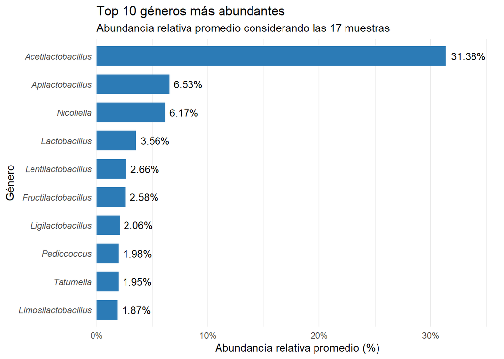

```r
# Grafica

ggplot(gen_10, aes(x = promedio * 100, y = reorder(genero, promedio))) +
  geom_col(fill = "#2C7BB6", width = 0.7) +
  geom_text(
    aes(label = paste0(round(promedio * 100, 2), "%")),
    hjust = -0.15,
    size = 3.5
  ) +
  scale_x_continuous(
    labels = function(x) paste0(x, "%"),
    expand = expansion(mult = c(0, 0.15))
  ) +
  labs(
    title = "Top 10 géneros más abundantes",
    subtitle = "Abundancia relativa promedio considerando las 17 muestras",
    x = "Abundancia relativa promedio (%)",
    y = "Género"
  ) +
  theme_minimal() +
  theme(
    panel.grid.major.y = element_blank(),
    axis.text.y = element_text(face = "italic")
  )
```

## Figura 2: composición bacteriana por muestra (30 puntos)

Utiliza las abundancias relativas del apartado 2, **no solamente los diez taxones de la figura anterior**.

- Dentro de cada muestra, agrupa los géneros cuya abundancia relativa sea estrictamente menor al 5 % en la categoría `Géneros < 5%`. Suma las abundancias de esa categoría.
- Construye una gráfica de barras apiladas, una barra por muestra, separando las especies de abejas mediante facetas. Cada barra debe sumar 100 %.
- Utiliza la paleta proporcionada y coloca la leyenda debajo de la gráfica.

Paleta de referencia (puedes copiarla en un bloque de R) o puedes usar otra paleta de colores:

**Código**

```r
cat('_____________________________________________________________________\n')
```

```
_____________________________________________________________________
```

**Código**

```r
genus_colors <- c(
  "Acetilactobacillus" = "#002868",
  "Apilactobacillus" = "#0077C2",
  "Lactobacillus" = "#66B2FF",
  "Nicoliella" = "#ADD8E1",
  "Pantoea" = "#008080",
  "Tatumella" = "#98FB98",
  "Fructobacillus" = "#007BA7",
  "Géneros < 5%" = "#778899"
)
```

[figure not shown]

Figura 2. Referencia.

**Código**

```r
cat('_____________________________________________________________________\n')
```

```
_____________________________________________________________________
```

**Código**

```r
# Generos < 5%
generos <- abundancia_rel %>%
  left_join(meta %>% select(sample_id, species) %>%
              distinct(), by = "sample_id") %>%
  mutate(genero = ifelse(abundancia_relativa < 0.05,
                         "Géneros < 5%", genero)) %>%
  group_by(sample_id, species, genero) %>%
  summarise(abundancia_relativa = sum(abundancia_relativa), .groups = "drop")

cat('_____________________________________________________________________\n')
```

```
_____________________________________________________________________
```

**Código**

```r
# Orden
orden_generos <- c(
  sort(setdiff(unique(generos$genero), "Géneros < 5%")),
  "Géneros < 5%"
)

generos$genero <- factor(generos$genero, levels = orden_generos)

cat('_____________________________________________________________________\n')
```

```
_____________________________________________________________________
```

**Código**

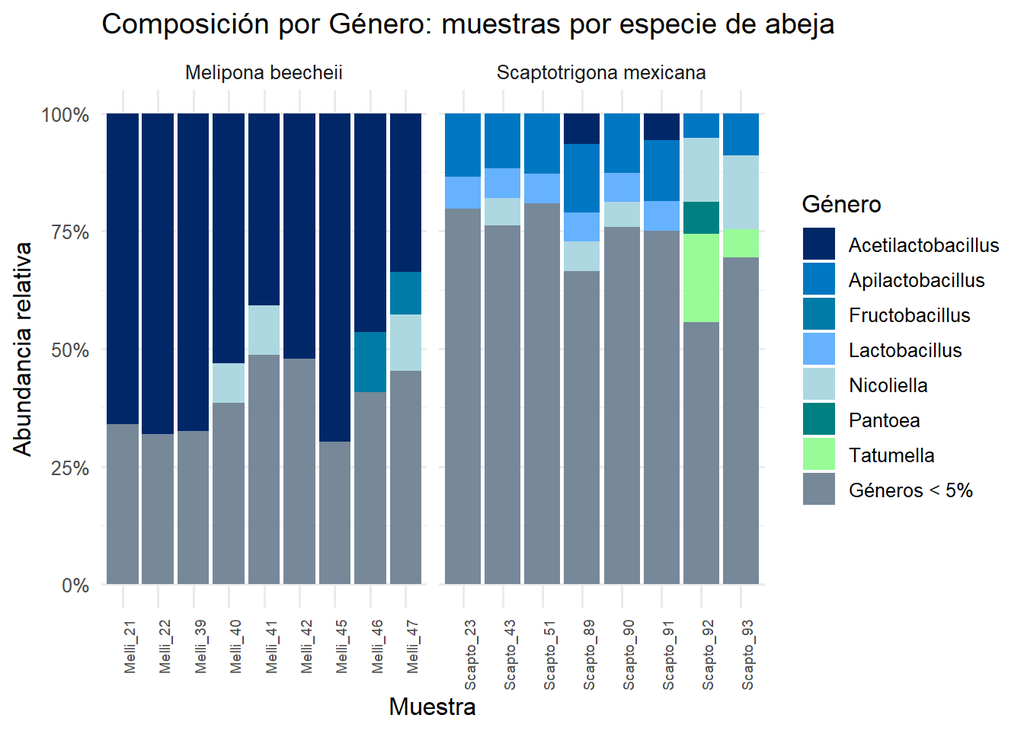

```r
# Gráfica
g_men_5 <- ggplot(generos,
                  aes(x = sample_id, y = abundancia_relativa,
                      fill = genero)
) +
  geom_col() +
  facet_wrap(~ species, scales = "free_x") +
  scale_fill_manual(values = genus_colors,
                    breaks = orden_generos) +
  scale_y_continuous(labels = function(x) paste0(round(100 * x), "%")) +
  labs(title = "Composición por Género: muestras por especie de abeja",
       x = "Muestra", y = "Abundancia relativa", fill = "Género") +
  theme_minimal(base_size = 12) +
  theme(axis.text.x = element_text(angle = 90, hjust = 1, size = 7))

g_men_5
```

## Interpretación (5 puntos)

Responde brevemente con base en tus resultados:

1. ¿Cuál es el género con mayor abundancia relativa promedio? El genero $Acetilactobacillus$, predomina en *Melipona beecheii* y la mayoria compone mas del 50% de las barras de esa especie.
2. ¿Qué diferencias o similitudes observas en la composición de las muestras de las dos especies de abejas? El genero dominante en *Melipona beecheii* es $Acetilactobacillus$ mientras que en *Scaptotrigona mexicana* es $Apilactobacillus$. En ambos los generos menores al 5% componen una gran parte de las muestras. Hay mas divercidad de generos en *Scaptotrigona mexicana*

**Nota**: Todas las muestras pertenecen al mismo estudio y fueron procesadas con la misma metodología.

## Reporte reproducible y entrega (10 puntos)

Renderiza el documento a HTML y sube a tu repositorio de GitHub el archivo `.qmd`, el HTML generado y las carpetas de datos y figuras necesarias. Verifica que el HTML muestre tus resultados y gráficas sin necesidad de ejecutar el código nuevamente. Entrega el enlace al repositorio.

Si tienes un problema técnico con GitHub, conserva el `.qmd` y el HTML y notifícalo a la profesora antes de finalizar el examen.